# Modeling_project_group

2025-02-10

## Group/general info

#Purpose: This is an R Markdown document for the modeling group project…

```r
library(vegan)
```

#Parameters for Table 1 in the paper - setting parameters for the models

#Emma (equation 1)

```r
#change in proportional live coral on the reef over time (dCL/dt)
#equation_1 <- gc*CL*S + gammaC*S - gmc*CL*(ME+MP) - dc*CL
```

#Addie (equation 2)

```r
#dCD/dt
#equation_2 <- dc*(CL+CP)+ MP*(h*(1-p)+dm)- gc*CP*CD-S*gammaC*CD-gm*CD*(ME+MP) - gammaM*CD- e*CD
```

#Mads (equation 3)

```r
#change in proportional cover of live coral growing on dead coral over time (dCP/dt)
#dCP/dt = GC* CP*CD + s*gammaC*CD - gmc*CP*(ME+MP) - dc*CP - e*CP
#equation_3 <- gc*CP*CD + settlement*gammaC*CD - gmc*CP*(ME + MP) - dc*CP - e*CP
```

#Equation 4

```r
#dME/dt= gm*ME*S + gammaM*S - ME(h+dm)
#equation_4 <- gm*ME*S + gammaM*S - ME*(h+dm)
```

#Equation 5

```r
#dMP/dt = gm*MP*CD +gm*ME*CD + gmc*CL(ME+MP) +gmc*CP*(ME+MP) + gammaM*CD - MP(h(1-p) +dm + e)
#equation_5 <- gm*MP*CD +gm*ME*CD + gmc*CL*(ME+MP) +gmc*CP*(ME+MP) + gammaM*CD - MP*(h*(1-p) +dm + e)
```

#Equation 6

```r
#S = 1 - CL - CD - CP - ME - MP
#equation_6 <- 1 - CL - CD - CP - ME - MP
```

#Begin model simulation 1

#Initial conditions

```r
#VARIABLES
#CL  #live coral on open substrate
#CD  #dead coral
#CP #Live coral on dead coral
#ME #Exposed macroalgae
#MP #Protected macroalgae
#S #Empty space; colonizable by coral or macroalgae

#PARAMETERS (change in proportional cover/year)
gc <- 0.1 #growth rate of coral
gm <- 0.6 #growth rate of macroalgae
gmc <- 0.06 #Overgrowth rate of macroalgae onto live coral
dc <- 0.001 #Death rate of coral
dm <- 0.05 #Senescence rate of macroalgae
e <- 0.01 #Erosion rate of dead coral
gammaC <- 0.001 #Open settlement rate of coral
settlement <- 1 #Multiplier for rate of coral settlement onto dead coral
gammaM <- 0.001 #Open settlement rate of macroalgae
h <- 0.3 #Ambient herbivory rate
p <- 0.5 #Algal protection; degree to which ambient herbivory is reduced for protected macroalgae
```

#Set up our storage variables and fill them with our initial conditions. **Note:** Now we’ll need one for each “state” of the population.

#Struture Retaining, higher macrolgae growth rate

```r
# create a vector of timesteps
tset1 <- seq(from = 0, to = 1000, length.out = 10005)

# create holding vectors and fill initial conditions - inital conditions represent proportional cover of the benthos
CL.simu1 <- NaN*tset1; CL.simu1[1] <- 0.02  #live coral
CD.simu1 <- NaN*tset1; CD.simu1[1] <- 0.7 #dead coral
CP.simu1 <- NaN*tset1; CP.simu1[1] <- 0 #live coral on dead coral
ME.simu1 <- NaN*tset1; ME.simu1[1] <- 0.1 #exposed macroalgae
MP.simu1 <- NaN*tset1; MP.simu1[1] <- 0.18 #protected macroalgae
S.simu1 <- NaN*tset1; S.simu1[1] <- 0 #empty space, not sure what to put here

# for each timestep
for(i in 2:length(tset1)){
  # calculate change in time
    dt <- tset1[i]-tset1[i-1]

    # store placeholder variables
    CL <- CL.simu1[i-1]
    CD <- CD.simu1[i-1]
    CP <- CP.simu1[i-1]
    ME <- ME.simu1[i-1]
    MP <- MP.simu1[i-1]
   S <- S.simu1[i-1]

    # calculate change in resource level and population size
    dCL <- (gc*CL*S + gammaC*S - gmc*CL*(ME+MP) - dc*CL)*dt #equation 1
    dCD <- (dc*(CL+CP)+ MP*(h*(1-p)+dm) - gc*CP*CD - settlement*gammaC*CD - gm*CD*(ME+MP) - gammaM*CD - e*CD)*dt #equation 2
    dCP <- (gc*CP*CD + settlement*gammaC*CD - gmc*CP*(ME + MP) - dc*CP - e*CP)*dt #equation 3
    dME <- (gm*ME*S + gm*MP*S + gammaM*S - ME*(h+dm))*dt #equation 4
    dMP <- (gm*MP*CD + gm*ME*CD + gmc*CL*(ME+MP) + gmc*CP*(ME+MP) + gammaM*CD - MP*(h*(1-p) + dm + e))*dt #equation 5
   dS <- (1 - CL - CD - CP - ME - MP)*dt #can i do that??? #equation 6

    # calculate total size
    CL.simu1[i] <- CL + dCL
    CD.simu1[i] <- CD + dCD
    CP.simu1[i] <- CP + dCP
    ME.simu1[i] <- ME + dME
    MP.simu1[i] <- MP + dMP
    S.simu1[i] <- S + dS
}

#check loop worked
head(CL.simu1)
```

```
## [1] 0.02000000 0.01996441 0.01992834 0.01989192 0.01985528 0.01981854
```

```r
tail(MP.simu1)
```

```
## [1] 0.2020546 0.2020546 0.2020547 0.2020548 0.2020548 0.2020549
```

##plots

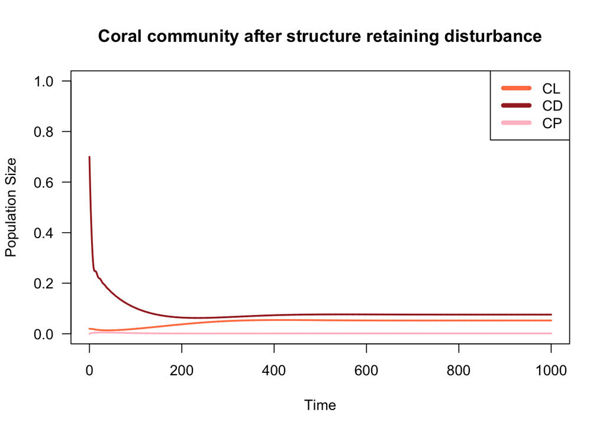

```r
#plot
# store colors for variables
CLcol <- 'coral'
CDcol <- 'brown'
CPcol <- 'pink'
MEcol <- 'seagreen'
MPcol <- 'green'
Scol <- 'gray'

# plot coral as a function of time
plot(x = tset1, y = CL.simu1,
     type = 'l', las = 1, lwd = 2, col = CLcol,
     ylim = c(0, 1),
     xlab = 'Time', ylab = 'Population Size',
     main = "Coral community after structure retaining disturbance")
 lines(x = tset1, y = CD.simu1,
      lwd = 2, col = CDcol)
 lines(x = tset1, y = CP.simu1,
      lwd = 2, col = CPcol )
 legend(x = 'topright', legend = c('CL', 'CD', 'CP'), lwd = 5, col = c(CLcol, CDcol, CPcol))
```

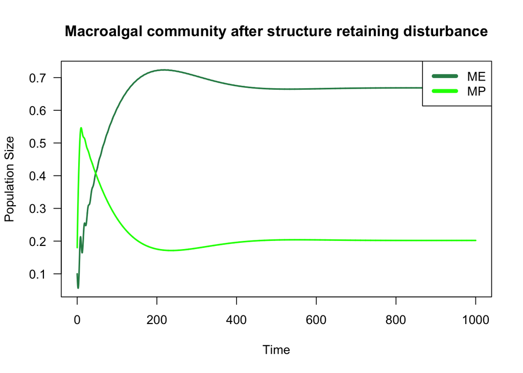

```r
# plot population macroalgae as a function of time
plot(x = tset1, y = ME.simu1,
     type = 'l', las = 1, lwd = 2, col = MEcol,
     xlab = 'Time', ylab = 'Population Size',
     main = "Macroalgal community after structure retaining disturbance")
lines(x = tset1, y = MP.simu1,
      lwd = 2, col = MPcol)
legend(x = 'topright', legend = c('ME', 'MP'), lwd = 5, col = c(MEcol, MPcol))
```

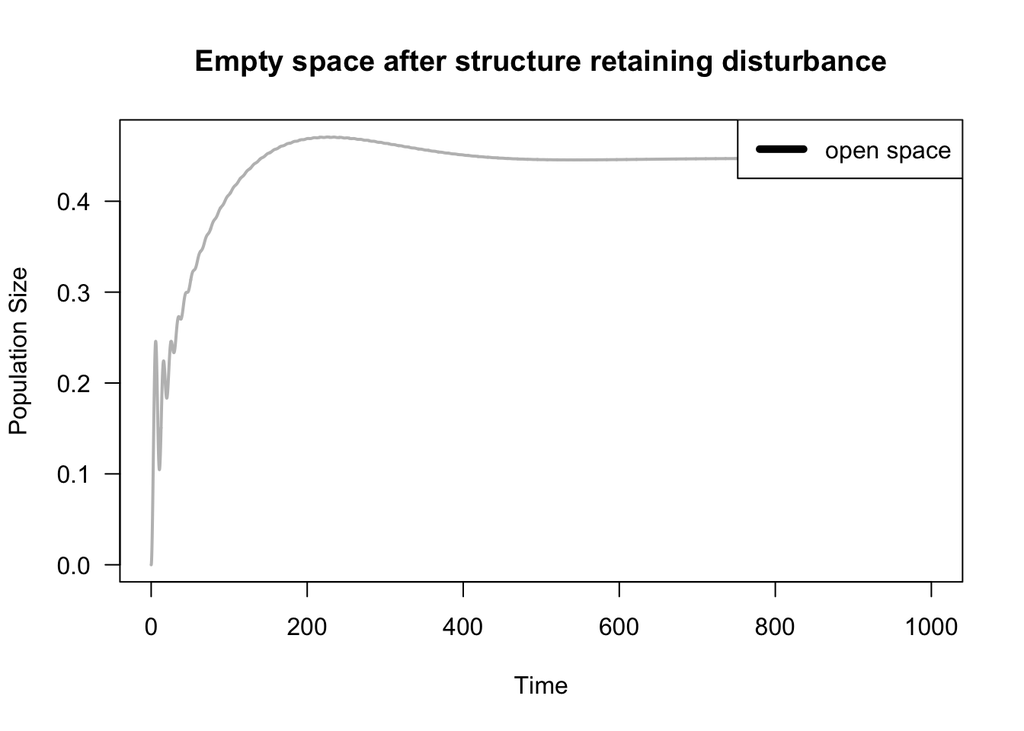

```r
# plot open space as a function of time
plot(x = tset1, y = S.simu1,
     type = 'l', las = 1, lwd = 2, col = "grey",
     xlab = 'Time', ylab = 'Population Size',
     main = "Empty space after structure retaining disturbance")
legend(x = 'topright', legend = c('open space'), lwd = 5)
```

#Structure Removing, higher macroalgae growth rate

```r
#create a vector of timesteps
tset1 <- seq(from = 0, to = 1000, length.out = 10005)

# create holding vectors and fill initial conditions - inital conditions represent proportional cover of the benthos
CL.simu2 <- NaN*tset1; CL.simu2[1] <- 0.05  #live coral
CD.simu2 <- NaN*tset1; CD.simu2[1] <- 0.1 #dead coral
CP.simu2 <- NaN*tset1; CP.simu2[1] <- 0 #live coral on dead coral
ME.simu2 <- NaN*tset1; ME.simu2[1] <- 0.1 #exposed macroalgae
MP.simu2 <- NaN*tset1; MP.simu2[1] <- 0.05 #protected macroalgae
S.simu2 <- NaN*tset1; S.simu2[1] <- 0.7 #empty space, not sure what to put here

# for each timestep
for(i in 2:length(tset1)){
  # calculate change in time
    dt <- tset1[i]-tset1[i-1]

    # store placeholder variables
    CL <- CL.simu2[i-1]
    CD <- CD.simu2[i-1]
    CP <- CP.simu2[i-1]
    ME <- ME.simu2[i-1]
    MP <- MP.simu2[i-1]
   S <- S.simu2[i-1]

    # calculate change in resource level and population size
    dCL <- (gc*CL*S + gammaC*S - gmc*CL*(ME+MP) - dc*CL)*dt #equation 1
    dCD <- (dc*(CL+CP)+ MP*(h*(1-p)+dm) - gc*CP*CD - settlement*gammaC*CD - gm*CD*(ME+MP) - gammaM*CD - e*CD)*dt #equation 2
    dCP <- (gc*CP*CD + settlement*gammaC*CD - gmc*CP*(ME + MP) - dc*CP - e*CP)*dt #equation 3
    dME <- (gm*ME*S + gm*MP*S + gammaM*S - ME*(h+dm))*dt #equation 4
    dMP <- (gm*MP*CD + gm*ME*CD + gmc*CL*(ME+MP) + gmc*CP*(ME+MP) + gammaM*CD - MP*(h*(1-p) + dm + e))*dt #equation 5
   dS <- (1 - CL - CD - CP - ME - MP)*dt #can i do that??? #equation 6

    # calculate total size
    CL.simu2[i] <- CL + dCL
    CD.simu2[i] <- CD + dCD
    CP.simu2[i] <- CP + dCP
    ME.simu2[i] <- ME + dME
    MP.simu2[i] <- MP + dMP
    S.simu2[i] <- S + dS
}

#check loop worked
head(CL.simu2)
```

```
## [1] 0.05000000 0.05036985 0.05078331 0.05124080 0.05174278 0.05228972
```

```r
tail(MP.simu2)
```

```
## [1] 0.2020927 0.2020928 0.2020930 0.2020932 0.2020934 0.2020937
```

## plots

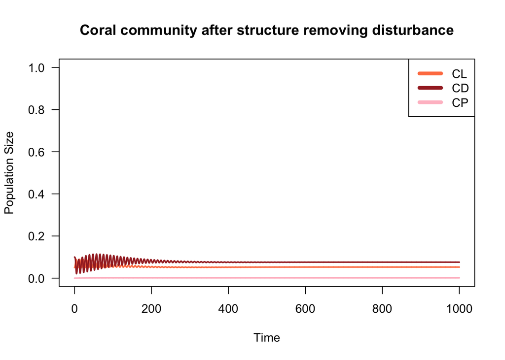

```r
# plot coral as a function of time
plot(x = tset1, y = CL.simu2,
     type = 'l', las = 1, lwd = 2, col = CLcol,
     ylim = c(0, 1),
     xlab = 'Time', ylab = 'Population Size',
     main = "Coral community after structure removing disturbance")
 lines(x = tset1, y = CD.simu2,
      lwd = 2, col = CDcol)
 lines(x = tset1, y = CP.simu2,
      lwd = 2, col = CPcol )
 legend(x = 'topright', legend = c('CL', 'CD', 'CP'), lwd = 5, col = c(CLcol, CDcol, CPcol))
```

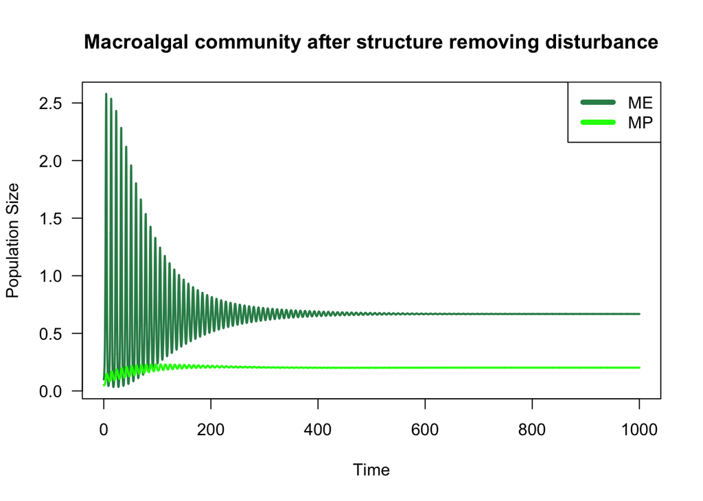

```r
# plot population macroalgae as a function of time
plot(x = tset1, y = ME.simu2,
     type = 'l', las = 1, lwd = 2, col = MEcol,
     xlab = 'Time', ylab = 'Population Size',
     main = "Macroalgal community after structure removing disturbance")
lines(x = tset1, y = MP.simu2,
      lwd = 2, col = MPcol)
legend(x = 'topright', legend = c('ME', 'MP'), lwd = 5, col = c(MEcol, MPcol))
```

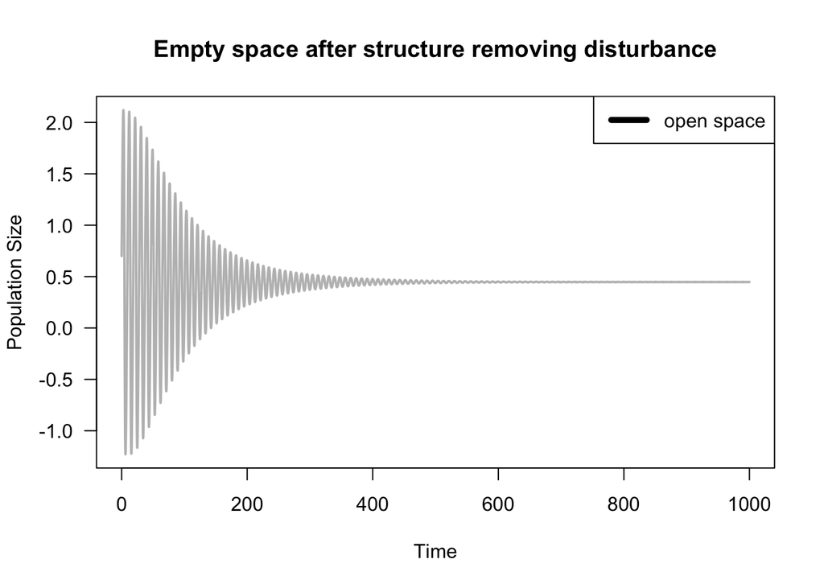

```r
# plot open space as a function of time
plot(x = tset1, y = S.simu2,
     type = 'l', las = 1, lwd = 2, col = "grey",
     xlab = 'Time', ylab = 'Population Size',
     main = "Empty space after structure removing disturbance")
legend(x = 'topright', legend = c('open space'), lwd = 5)
```

#Changing macroalgae growth rate from 0.6 to 0.3

#Structure retaining, lower macroalgae growth rate

```r
gm_2 <- 0.3 #DECREASING growth rate of macroalgae

# create a vector of timesteps
tset1 <- seq(from = 0, to = 1000, length.out = 10005)

# create holding vectors and fill initial conditions - inital conditions represent proportional cover of the benthos
CL.simu3 <- NaN*tset1; CL.simu3[1] <- 0.02  #live coral
CD.simu3 <- NaN*tset1; CD.simu3[1] <- 0.7 #dead coral
CP.simu3 <- NaN*tset1; CP.simu3[1] <- 0 #live coral on dead coral
ME.simu3 <- NaN*tset1; ME.simu3[1] <- 0.1 #exposed macroalgae
MP.simu3 <- NaN*tset1; MP.simu3[1] <- 0.18 #protected macroalgae
S.simu3 <- NaN*tset1; S.simu3[1] <- 0 #empty space, not sure what to put here

# for each timestep
for(i in 2:length(tset1)){
  # calculate change in time
    dt <- tset1[i]-tset1[i-1]

    # store placeholder variables
    CL <- CL.simu3[i-1]
    CD <- CD.simu3[i-1]
    CP <- CP.simu3[i-1]
    ME <- ME.simu3[i-1]
    MP <- MP.simu3[i-1]
   S <- S.simu3[i-1]

    # calculate change in resource level and population size
    dCL <- (gc*CL*S + gammaC*S - gmc*CL*(ME+MP) - dc*CL)*dt #equation 1
    dCD <- (dc*(CL+CP)+ MP*(h*(1-p)+dm) - gc*CP*CD - settlement*gammaC*CD - gm_2*CD*(ME+MP) - gammaM*CD - e*CD)*dt #equation 2
    dCP <- (gc*CP*CD + settlement*gammaC*CD - gmc*CP*(ME + MP) - dc*CP - e*CP)*dt #equation 3
    dME <- (gm_2*ME*S + gm_2*MP*S + gammaM*S - ME*(h+dm))*dt #equation 4
    dMP <- (gm_2*MP*CD + gm_2*ME*CD + gmc*CL*(ME+MP) + gmc*CP*(ME+MP) + gammaM*CD - MP*(h*(1-p) + dm + e))*dt #equation 5
   dS <- (1 - CL - CD - CP - ME - MP)*dt #can i do that??? #equation 6

    # calculate total size
    CL.simu3[i] <- CL + dCL
    CD.simu3[i] <- CD + dCD
    CP.simu3[i] <- CP + dCP
    ME.simu3[i] <- ME + dME
    MP.simu3[i] <- MP + dMP
    S.simu3[i] <- S + dS
}

#check loop worked
head(CL.simu3)
```

```
## [1] 0.02000000 0.01996441 0.01992905 0.01989403 0.01985947 0.01982551
```

```r
tail(MP.simu3)
```

```
## [1] 0.0005735496 0.0005735288 0.0005735023 0.0005734703 0.0005734326
## [6] 0.0005733894
```

## Plots

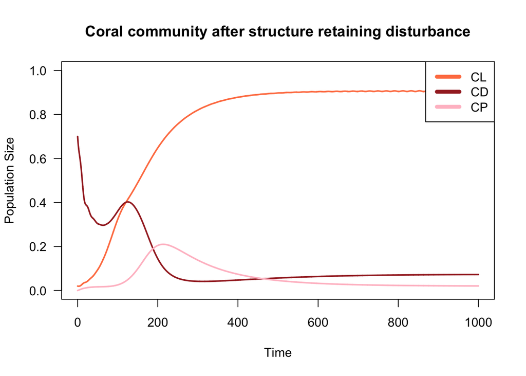

```r
# plot coral as a function of time
plot(x = tset1, y = CL.simu3,
     type = 'l', las = 1, lwd = 2, col = CLcol,
     ylim = c(0, 1),
     xlab = 'Time', ylab = 'Population Size',
     main = "Coral community after structure retaining disturbance")
 lines(x = tset1, y = CD.simu3,
      lwd = 2, col = CDcol)
 lines(x = tset1, y = CP.simu3,
      lwd = 2, col = CPcol )
 legend(x = 'topright', legend = c('CL', 'CD', 'CP'), lwd = 5, col = c(CLcol, CDcol, CPcol))
```

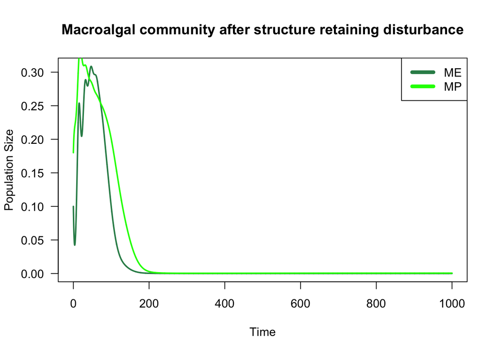

```r
# plot population macroalgae as a function of time
plot(x = tset1, y = ME.simu3,
     type = 'l', las = 1, lwd = 2, col = MEcol,
     xlab = 'Time', ylab = 'Population Size',
     main = "Macroalgal community after structure retaining disturbance")
lines(x = tset1, y = MP.simu3,
      lwd = 2, col = MPcol)
legend(x = 'topright', legend = c('ME', 'MP'), lwd = 5, col = c(MEcol, MPcol))
```

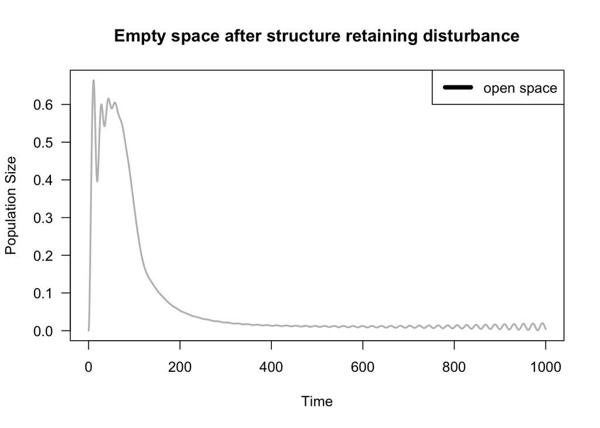

```r
# plot open space as a function of time
plot(x = tset1, y = S.simu3,
     type = 'l', las = 1, lwd = 2, col = "grey",
     xlab = 'Time', ylab = 'Population Size',
     main = "Empty space after structure retaining disturbance")
legend(x = 'topright', legend = c('open space'), lwd = 5)
```

#Structure removing, lower macroalgae growth rate

```r
# create a vector of timesteps
tset1 <- seq(from = 0, to = 1000, length.out = 10005)

# create holding vectors and fill initial conditions - inital conditions represent proportional cover of the benthos
CL.simu4 <- NaN*tset1; CL.simu4[1] <- 0.05  #live coral
CD.simu4 <- NaN*tset1; CD.simu4[1] <- 0.1 #dead coral
CP.simu4 <- NaN*tset1; CP.simu4[1] <- 0 #live coral on dead coral
ME.simu4 <- NaN*tset1; ME.simu4[1] <- 0.3 #exposed macroalgae
MP.simu4 <- NaN*tset1; MP.simu4[1] <- 0.05 #protected macroalgae
S.simu4 <- NaN*tset1; S.simu4[1] <- 0.5 #empty space, not sure what to put here

# for each timestep
for(i in 2:length(tset1)){
  # calculate change in time
    dt <- tset1[i]-tset1[i-1]

    # store placeholder variables
    CL <- CL.simu4[i-1]
    CD <- CD.simu4[i-1]
    CP <- CP.simu4[i-1]
    ME <- ME.simu4[i-1]
    MP <- MP.simu4[i-1]
   S <- S.simu4[i-1]

    # calculate change in resource level and population size
    dCL <- (gc*CL*S + gammaC*S - gmc*CL*(ME+MP) - dc*CL)*dt #equation 1
    dCD <- (dc*(CL+CP)+ MP*(h*(1-p)+dm) - gc*CP*CD - settlement*gammaC*CD - gm_2*CD*(ME+MP) - gammaM*CD - e*CD)*dt #equation 2
    dCP <- (gc*CP*CD + settlement*gammaC*CD - gmc*CP*(ME + MP) - dc*CP - e*CP)*dt #equation 3
    dME <- (gm_2*ME*S + gm_2*MP*S + gammaM*S - ME*(h+dm))*dt #equation 4
    dMP <- (gm_2*MP*CD + gm_2*ME*CD + gmc*CL*(ME+MP) + gmc*CP*(ME+MP) + gammaM*CD - MP*(h*(1-p) + dm + e))*dt #equation 5
   dS <- (1 - CL - CD - CP - ME - MP)*dt #can i do that??? #equation 6

    # calculate total size
    CL.simu4[i] <- CL + dCL
    CD.simu4[i] <- CD + dCD
    CP.simu4[i] <- CP + dCP
    ME.simu4[i] <- ME + dME
    MP.simu4[i] <- MP + dMP
    S.simu4[i] <- S + dS
}

#check loop worked
head(CL.simu4)
```

```
## [1] 0.05000000 0.05018992 0.05041198 0.05066662 0.05095430 0.05127551
```

```r
tail(MP.simu4)
```

```
## [1] 0.006290270 0.006176817 0.006065903 0.005957491 0.005851541 0.005748019
```

## Plots

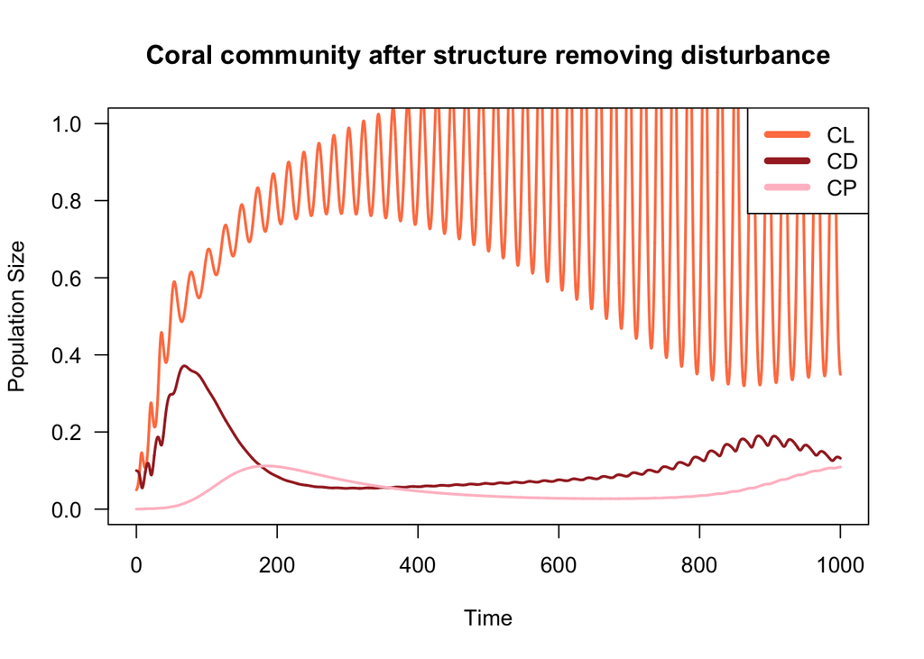

```r
# plot coral as a function of time
plot(x = tset1, y = CL.simu4,
     type = 'l', las = 1, lwd = 2, col = CLcol,
     ylim = c(0, 1),
     xlab = 'Time', ylab = 'Population Size',
     main = "Coral community after structure removing disturbance")
 lines(x = tset1, y = CD.simu4,
      lwd = 2, col = CDcol)
 lines(x = tset1, y = CP.simu4,
      lwd = 2, col = CPcol )
 legend(x = 'topright', legend = c('CL', 'CD', 'CP'), lwd = 5, col = c(CLcol, CDcol, CPcol))
```

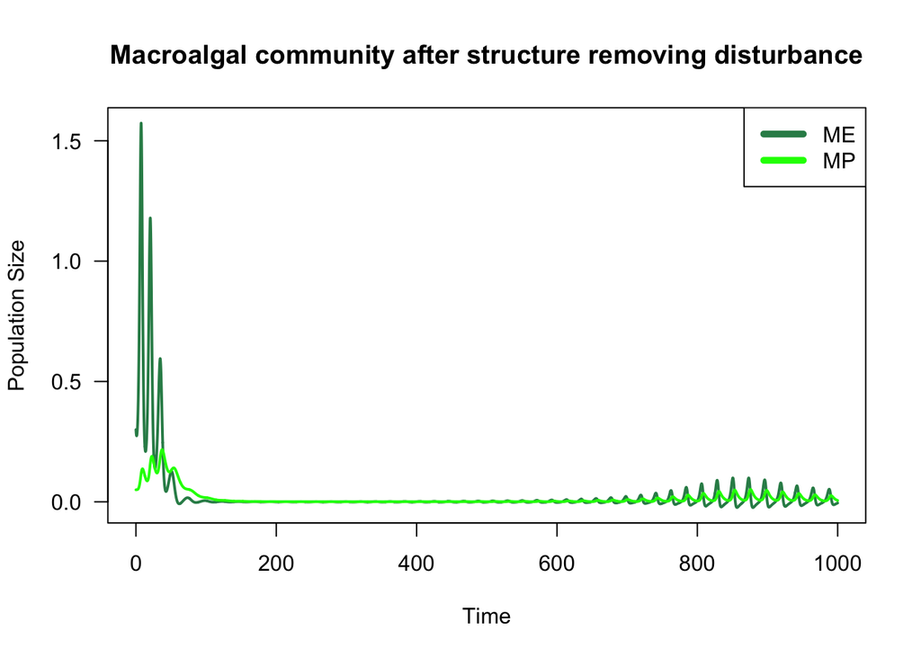

```r
# plot population macroalgae as a function of time
plot(x = tset1, y = ME.simu4,
     type = 'l', las = 1, lwd = 2, col = MEcol,
     xlab = 'Time', ylab = 'Population Size',
     main = "Macroalgal community after structure removing disturbance")
lines(x = tset1, y = MP.simu4,
      lwd = 2, col = MPcol)
legend(x = 'topright', legend = c('ME', 'MP'), lwd = 5, col = c(MEcol, MPcol))
```

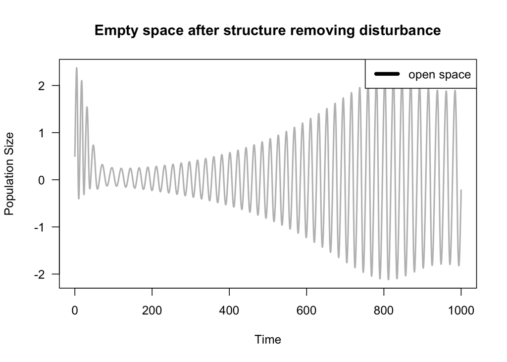

```r
# plot open space as a function of time
plot(x = tset1, y = S.simu4,
     type = 'l', las = 1, lwd = 2, col = "grey",
     xlab = 'Time', ylab = 'Population Size',
     main = "Empty space after structure removing disturbance")
legend(x = 'topright', legend = c('open space'), lwd = 5)
```

#NEXT STEPS: ###update simu above for structure retaining vs removing (DONE) - this is showing weird oscillations?

###pick param to change (macro growth rate) and re-run each simu with new growth of macroalgae (DONE)

###bifurcation diagram of macro growth rate against live coral cover?

#Bifurcation diagram - macroalgae growth rate

```r
gmset <- seq(from = 0, to = 0.1,length.out = 50) #dont know what numbers to put here

CLstarset <- NaN*gmset
MEstarset <- NaN*gmset

CDstarset <- NaN*gmset
CPstarset <- NaN*gmset
MPstarset <- NaN*gmset
Sstarset <- NaN*gmset

for(j in 1:length(gmset)){
    gm <- gmset[j]

#holding vectors and initial conditions for live coral and exposed macroalgae cover
    CL.simu5 <- NaN*tset1; CL.simu5[1] <-  0.02
    ME.simu5 <- NaN*tset1; ME.simu5[1] <- 0.1

    CD.simu5 <- NaN*tset1; CD.simu5[1] <- 0.7 #dead coral
    CP.simu5 <- NaN*tset1; CP.simu5[1] <- 0 #live coral on dead coral
    MP.simu5 <- NaN*tset1; MP.simu5[1] <- 0.18 #protected macroalgae
    S.simu5 <- NaN*tset1; S.simu5[1] <- 0 #empty space, not sure what to put here

    for(i in 2:length(tset1)){
        dt <- tset1[i]-tset1[i-1]

        # storing temporary variables
        CL <- CL.simu5[i-1]
        ME <- ME.simu5[i-1]

        CD <- CD.simu5[i-1]
        CP <- CP.simu5[i-1]
        MP <- MP.simu5[i-1]
        S <- S.simu5[i-1]

        # calculating change in population size
        dCL <- (gc*CL*S + gammaC*S - gmc*CL*(ME+MP) - dc*CL)*dt
        dME <- (gm_2*ME*S + gm*MP*S + gammaM*S - ME*(h+dm))*dt

        dCD <- (dc*(CL+CP)+ MP*(h*(1-p)+dm) - gc*CP*CD - settlement*gammaC*CD - gm*CD*(ME+MP) - gammaM*CD - e*CD)*dt
          dCP <- (gc*CP*CD + settlement*gammaC*CD - gmc*CP*(ME + MP) - dc*CP - e*CP)*dt
          dMP <- (gm*MP*CD + gm*ME*CD + gmc*CL*(ME+MP) + gmc*CP*(ME+MP) + gammaM*CD - MP*(h*(1-p) + dm + e))*dt
        dS <- (1 - CL - CD - CP - ME - MP)*dt

        # calculating total population size
        CL.simu5[i] <- CL.simu5[i-1] + dCL
        ME.simu5[i] <- ME.simu5[i-1] + dME

        CD.simu5[i] <- CD.simu5[i-1] + dCD
        CP.simu5[i] <- CP.simu5[i-1] + dCP
          MP.simu5[i] <- MP.simu5[i-1] + dMP
          S.simu5[i] <- S.simu5[i-1] + dS

    }}

    # storing last population size (equilibrium population size) in holding vector
    CLstarset[j] <- CL.simu5[length(tset1)]
    MEstarset[j] <- ME.simu5[length(tset1)]

    CDstarset[j] <- CD.simu5[length(tset1)]
    CPstarset[j] <- CP.simu5[length(tset1)]
    MPstarset[j] <- MP.simu5[length(tset1)]
    Sstarset[j] <- S.simu5[length(tset1)]
```

## Plots

[figure not shown]

```r
#Live coral bifurcation diagram
plot(x = gmset, y = CLstarset,
     type = 'l', lwd = 2, col = CLcol, las = 1,
     xlab = 'Growth Rate of Macroalgae, gm', ylab = 'Stable equilibria of Live Coral Cover, CL*',
     ylim = )
```

[figure not shown]

```r
#Exposed Macroalgae bifurcation diagram
plot(x = gmset, y = MEstarset,
     type = 'l', lwd = 2, col = MEcol, las = 1,
     xlab = 'Growth Rate of Macroalgae, gm', ylab = 'Stable equilibria of Exposed Macroalgae, ME*')
```

#FROM GUIDELINES: At least one figure* presenting time-series simulations of the model. This figure should show how outcomes differ as a function of an interesting parameter(s). Make sure your figure includes a caption! (If you have many state variables, sometimes it’s helpful for this to be split into two or more figures.)

At least one figure* presenting a bifurcation diagram with respect to an interesting parameter. Make sure your figure includes a descriptive caption!